# iris_data_set_vm7 (ready for html and PDF)

Han Oostdijk (www.hanoostdijk.nl)

25Jun2017

# Functions that enable captions to figures and tables

This document contains two sets of functions in the child chunk *captions_html_latex.rmd*. One set is used for html documents and the other for pdf documents. For pdf documents it does not work with the output *pdf_document* so it is necessary to use *bookdown::pdf_document2* . With the (default) Pandoc template for this output type a table of contents is produced. The table of contents can be omitted by specifying **toc:no** in the yaml header.

We use a child chunk because the code in it is also available for other documents.

# Defines captions for plot and table

```r
init_caption('Figure','Table')           # indicate prefix for figures and tables
add_caption("fig1","f","my first plot")  # define a caption for the first (an only) figure
add_caption("tab1","t","my first table") # define a caption for the first (an only) table
```

# Libraries used

```r
library(knitr)
library(pander)
library(ggplot2)
library(ggthemes)
```

# Load data

We load the iris data set in the workspace.

```r
data(iris)
```

# List the part of the iris data set

We list the first 5 (because we set variable *numlist* to 5 in a chunck we do not present to the reader) observations in the data set. See Table 1

```r
  pandoc.table(iris[1:numlist,],caption=tab_caption("tab1"))
```

Table 1: my first table

| Sepal.Length | Sepal.Width | Petal.Length | Petal.Width | Species |
| --- | --- | --- | --- | --- |
| 5.1 | 3.5 | 1.4 | 0.2 | setosa |
| 4.9 | 3 | 1.4 | 0.2 | setosa |
| 4.7 | 3.2 | 1.3 | 0.2 | setosa |
| 4.6 | 3.1 | 1.5 | 0.2 | setosa |
| 5 | 3.6 | 1.4 | 0.2 | setosa |

# Create a plot of the iris data set

Make a *ggplot2* plot object *p* of two variables in the iris data set and use it to create a plot that is shown in Figure 1

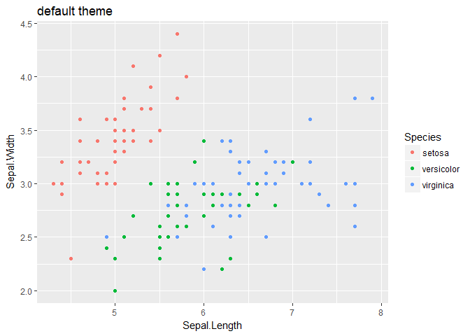

Figure 1: my first plot

```r
p <- ggplot(iris, aes(Sepal.Length, Sepal.Width, colour = Species)) +
  geom_point()
p + labs(title = 'default theme')
```